# Stablecoins — compare USDC, USDT and DAI transaction sizes and volumes

We want to compare three major Ethereum stablecoins:

- USDC (smart contract address: 0xa0b86991c6218b36c1d19d4a2e9eb0ce3606eb48)
- USDT (smart contract address: 0xdac17f958d2ee523a2206206994597c13d831ec7)
- DAI (smart contract address: 0x6b175474e89094c44da98b954eedeac495271d0f)

We will investigate two questions:

1. How do their transfer sizes differ?
2. How much transfer volume does each stablecoin generate?

Our workflow is:

```
Ethereum
   ↓
Etherscan
   ↓
ERC-20 transfer events
   ↓
R / tidyverse
   ↓
transfer sizes + transfer volumes
```

We use Etherscan to retrieve the already indexed ERC-20 transfer events. Etherscan’s `tokentx` endpoint can be filtered directly by token contract, so we do not need to download unrelated ERC-20 transfers first.

We use the term transfer rather than transaction throughout the lab: one Ethereum transaction can generate several ERC-20 transfer events.

```r
# Setup
library(tidyverse)
library(httr2)
```

```r
api_key <- Sys.getenv("ETHERSCAN_API_KEY")
# Set wd
data_dir <- if (basename(getwd()) == "Stablecoins") "data" else file.path("Stablecoins", "data")

fetch_tokens <- function(address, name) {
  response <- request("https://api.etherscan.io/v2/api") |>
    req_url_query(
      chainid = 1,
      module = "account",
      action = "tokentx",
      address = address,
      startblock = 0,
      endblock = 99999999,
      page = 1,
      offset = 1000,
      sort = "asc",
      apikey = api_key
    ) |>
    req_perform() |>
    resp_body_json(simplifyVector = TRUE)

  tokens <- response$result |>
    as_tibble()

  dir.create(data_dir, showWarnings = FALSE, recursive = TRUE)
  write_csv(tokens, file.path(data_dir, paste0(name, ".csv")))
  tokens
}

# Save tokens files for each coin
USDC <- fetch_tokens("0xa0b86991c6218b36c1d19d4a2e9eb0ce3606eb48", "USDC")
USDT <- fetch_tokens("0xdac17f958d2ee523a2206206994597c13d831ec7", "USDT")
DAI <-fetch_tokens("0x6b175474e89094c44da98b954eedeac495271d0f", "DAI")
```

### 1. How do the coins transfer sizes differ?

```r
# Combine the datasets, filter to legitimate token transfers, and convert to USD to compare
all_transfers <- bind_rows(
  USDC = USDC,
  USDT = USDT,
  DAI  = DAI,
  .id = "coin"
) |>
  filter(tokenSymbol == coin) |>
  mutate(value = as.numeric(value) / (10 ^ as.numeric(tokenDecimal))) |>
  filter(value >= 0.01) # excluding failed transactions

# Computing stats
transfer_sizes <- all_transfers |>
  group_by(coin) |>
  summarise(
    n_transfers = n(),
    median = median(value, na.rm = TRUE),
    mean = mean(value, na.rm = TRUE),
    p25 = quantile(value, 0.25, na.rm = TRUE),
    p75 = quantile(value, 0.75, na.rm = TRUE),
    max = max(value, na.rm = TRUE)
  )

transfer_sizes
```

```
## # A tibble: 3 × 7
##   coin  n_transfers median  mean   p25   p75     max
##   <chr>       <int>  <dbl> <dbl> <dbl> <dbl>   <dbl>
## 1 DAI           607   26.3  952.  6.08 158.  201000
## 2 USDC          673   50   2552.  9.02 381.  858624.
## 3 USDT          756    5    842.  1.43  27.7 100000
```

The transfer sizes differ significantly across the three stablecoins: - **USDC** shows the largest transfer sizes, with the highest median ($50.00) and mean ($2,552.00). - **DAI** has intermediate transfer sizes, with a median of $26.33. - **USDT** exhibits the smallest transfer sizes, with a median of just $5.00 and 75% of transfers under $28, reflecting more high-frequency or retail-like transactions.

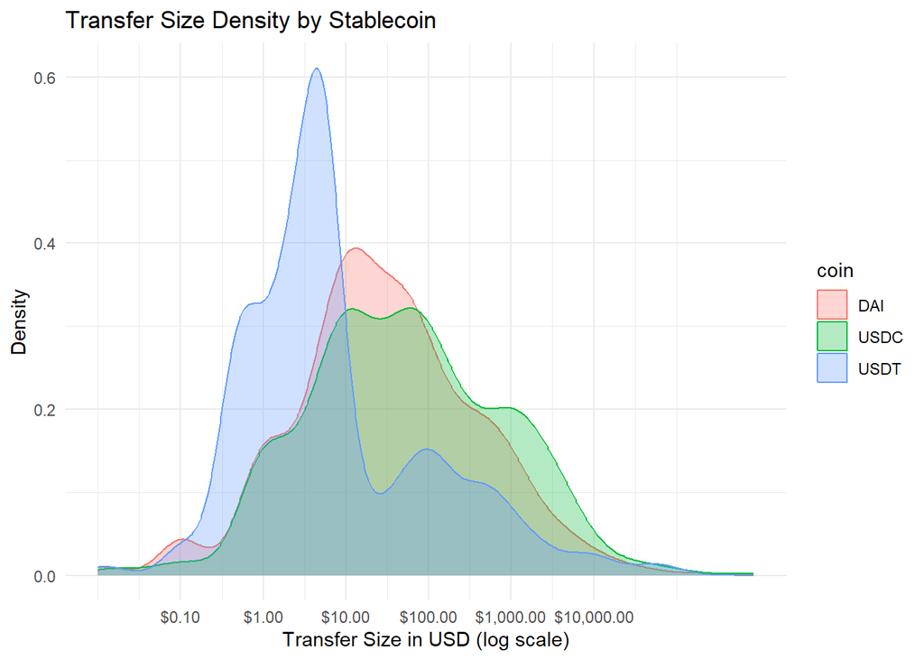

```r
# Density function plot to see the differences
ggplot(all_transfers, aes(x = value, fill = coin, color = coin)) +
  geom_density(alpha = 0.3) +
  scale_x_log10(
    breaks = c(0.1, 1, 10, 100, 1000, 10000),
    labels = scales::dollar_format()
  ) +
  labs(
    title = "Transfer Size Density by Stablecoin",
    x = "Transfer Size in USD (log scale)",
    y = "Density"
  ) +
  theme_minimal()
```

### 2. How much transfer volume does each stablecoin generate?

```r
transfer_volumes <- all_transfers |>
  group_by(coin) |>
  summarise(
    total_volume_usd = sum(value, na.rm = TRUE)
  ) |>
  mutate(
    volume_share_pct = round(100 * total_volume_usd / sum(total_volume_usd), 2)
  ) |>
  arrange(desc(total_volume_usd))

transfer_volumes
```

```
## # A tibble: 3 × 3
##   coin  total_volume_usd volume_share_pct
##   <chr>            <dbl>            <dbl>
## 1 USDC          1717536.             58.6
## 2 USDT           636598.             21.7
## 3 DAI            577598.             19.7
```

Across the analyzed sample: - **USDC** generates the majority of the transfer volume, with approximately **58.6%** of total volume. - **USDT** generates **21.7%** of total volume, despite recording the highest number of transfers (756), because its individual transfers are much smaller. - **DAI** generates **19.7%** of total volume, having a comparable percentage with USDT, even though it has a lower number of transactions.

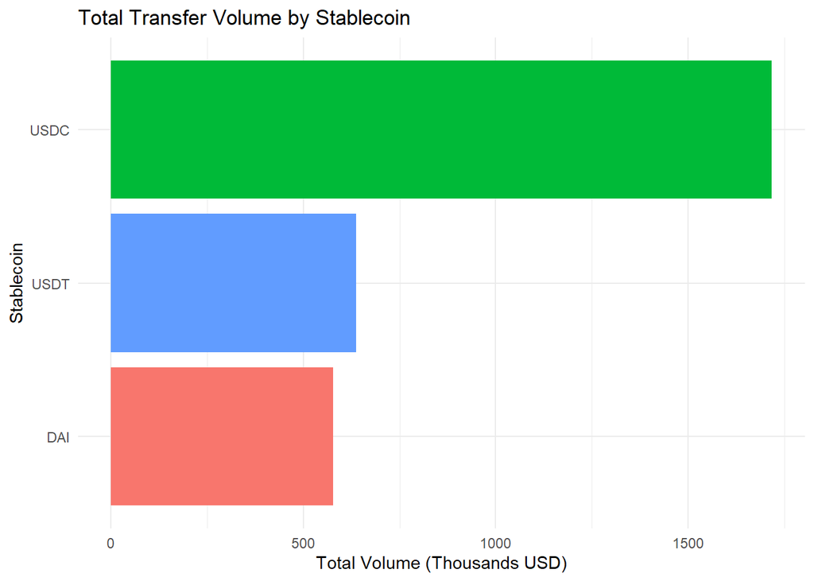

```r
ggplot(transfer_volumes, aes(x = fct_reorder(coin, total_volume_usd), y = total_volume_usd / 1e3, fill = coin)) +
  geom_col() +
  coord_flip() +
  labs(
    title = "Total Transfer Volume by Stablecoin",
    x = "Stablecoin",
    y = "Total Volume (Thousands USD)"
  ) +
  theme_minimal() +
  theme(legend.position = "none")
```